# SpatialScienceLinearAlgebra

Ivann Schlosser

4/20/2021

## Introduction

This online resource is inteded to help fill a certain gap that people might find when coming to the field of spatial data science from non technical backgrounds. It does not aim at covering the material at a college science degree level, but rather in a simple way present the main results, how are they obtained and most importantly how are they usefull. It is all wrapped up in the R working environment provided by Rstudio. (have a section that explains installation ?) Let’s start with the most basic things so that the essentials are clarified, the foundation is strong and we are ready climb up.

### Variables

A variable is something that is not necessarily known and that changes independently of the system we are dealing with. Variables can be represented in different ways, but the most usefull and frequent is to assign them to a letter, x or y for example.

#### Sets

When we are dealing with multiple variables, or variables take multiple values, it is convenient to define sets. Actually, sets are a very important part of math and the subject can get very complicated, we will be working with them on a very basic level for now. Sets are usually named with capital letters, like A, B, C, R, N etc… We can specify the elements that belong to a specific set by including them in semi colons, for example the infinite set of even numbers $\{0,2,4,6,8,...\}$. Some sets have conventional names, like the set of positive integers $N = \{0,1,2,3,4,5,6,7,8,9,10,...\}$, or the set of integers $Z = \{...,-5,-4,-3,-2,-1,0,1,2,3,4,5,...\}$. From these definitions, we can see that actually the whole set $N$ is included in $Z$, in this case we can write $N \subset Z$. It’s called a subset.

##### Operations on sets

Let’s have a look at what we can do with sets. Let’s have 2 exmaple sets: $A = \{ a,b,c,d,e,f\}$ and $B = \{d,e,f,g,h\}$. There is a multitude of operations that can be performed with sets and with elements of sets. Let’s look at the some basic ones. First, the union of sets, which is also a set, denoted $C = A \cup B = \{a,b,c,d,e,f,g,h\}$. C is a set that has all the elements of A and B, it is the result of the union of sets. Note that we don’t count elements twice.

#### Axes, coordinates and representation

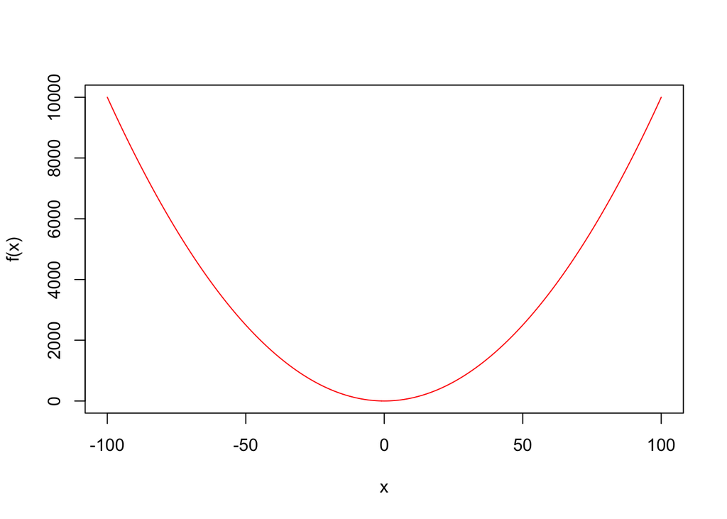

```r
x <- c(-100:100)

square <- function(x) {
  return(x*x)
}

plot(x,square(x), type = "l", col = "red", ylab = "f(x)")
```

This chunk of code, although short, contains a lot of information, mainly about the programming language we are working with, R. R is a vector based language which means that you encode each variable as an ordered set of elements. In this case and for now, we looked at the most simple variable, which is just 1 number, x. It can take the value of any real number, but we limit ourselves to an interval between -100 and 100, this is done by the first row of code. Next, we define our function, the proper way to do it is start with the name, square, then specify that it will be a function, and then put into brackets the variable that the function depends on. As of now we have only one, but it can be more as we will see. The body of the function is contained within the semi colons ${...}$ and contains all the operations that the function does to the variable, and the final output is returned by the $return()$ command. Finally we plot it.

#### Vectors

So far, a variable has been represented by one element, but what if we could generalise this ? Let’s call a vector variable one which is composed of several simpler variables that are arranged in a specific order. There are various notations, the most common is putting an arrow on top of the letter that represents the variable, or making it bold :
$$\vec{a} =\mathbf{a} = (x_1,x_2,...,x_n)$$
where the indexe of the element is its position. In this case, $\vec{a}$ is a n-dimensional vector since it is composed of n different variables.

Now, let’s stick to the case n = 2 for now, $\vec{a} = (x_1,x_2)$. This vector can help us localise any point on a 2D plane. If we define the first element to be the conventional x axis and $x_2$ to be the y axis, we can assign a vector to any point $\vec{a}$ to any point of the plane.

Working with this and the function that we defined earlier, we can rewrite it as follows:
$$\vec{f}(x) = (x,x^2)$$
. Usually, in order to avoid mixing up the variable with the axis names, we introduce a variable $t=x$, and hence end up with something called a parametric function
$$\vec{f}(t) = (t,t^2)$$
. It is implied here that the first variable corresponds to values on the x axis and the second to the y axis. And now using intervals we can define the area on which this function is defined, or the area of interest to us for this function, $t \in [-1,1]$ for example if we want to see how the function behaves around 0. Using the most simple example of a function and the definition of a vector we already can make prety complex things like parametric functions. The name of the variable $t$ here refers to time as it is usually how time dependent equation used in physics.